# knn_wine_classification_upgrade_crossvalidation

### KNN for classification problems, by weld

This notebook introduces first the notion of K-NN which stands for k-nearest neighbors algorithm. The former notebook did not use any kind of optimization. It tries to correct this. I tried to comment as much line I can. For the few that are not, I hope they are self-explanatory.

Made by weld, 18/04/20.

```python
%matplotlib inline
```

```python
import numpy as np
import pandas as pd
import matplotlib.pyplot as plt
import matplotlib.ticker as ticker
```

The datas we want to use are embedded in SciKit-Learn.

```python
from sklearn.datasets import load_wine
wine = load_wine()

'''Grab some informations about wine dataset'''
print(wine.keys())
```

```
dict_keys(['data', 'target', 'target_names', 'DESCR', 'feature_names'])
```

```python
print(wine.DESCR)
```

```
.. _wine_dataset:

Wine recognition dataset
------------------------

**Data Set Characteristics:**

    :Number of Instances: 178 (50 in each of three classes)
    :Number of Attributes: 13 numeric, predictive attributes and the class
    :Attribute Information:
 		- Alcohol
 		- Malic acid
 		- Ash
		- Alcalinity of ash
 		- Magnesium
		- Total phenols
 		- Flavanoids
 		- Nonflavanoid phenols
 		- Proanthocyanins
		- Color intensity
 		- Hue
 		- OD280/OD315 of diluted wines
 		- Proline

    - class:
            - class_0
            - class_1
            - class_2

    :Summary Statistics:

    ============================= ==== ===== ======= =====
                                   Min   Max   Mean     SD
    ============================= ==== ===== ======= =====
    Alcohol:                      11.0  14.8    13.0   0.8
    Malic Acid:                   0.74  5.80    2.34  1.12
    Ash:                          1.36  3.23    2.36  0.27
    Alcalinity of Ash:            10.6  30.0    19.5   3.3
    Magnesium:                    70.0 162.0    99.7  14.3
    Total Phenols:                0.98  3.88    2.29  0.63
```

[output cut: 40 more lines]

```
  Tech. Rep. no. 92-02, (1992), Dept. of Computer Science and Dept. of
  Mathematics and Statistics, James Cook University of North Queensland.
  (Also submitted to Technometrics).

  The data was used with many others for comparing various
  classifiers. The classes are separable, though only RDA
  has achieved 100% correct classification.
  (RDA : 100%, QDA 99.4%, LDA 98.9%, 1NN 96.1% (z-transformed data))
  (All results using the leave-one-out technique)

  (2) S. Aeberhard, D. Coomans and O. de Vel,
  "THE CLASSIFICATION PERFORMANCE OF RDA"
  Tech. Rep. no. 92-01, (1992), Dept. of Computer Science and Dept. of
  Mathematics and Statistics, James Cook University of North Queensland.
  (Also submitted to Journal of Chemometrics).
```

Okey, so there are 3 classes matching the 3 different cultivators. Our purpose here is to use a classifier to determine if the wine belongs to a cultivator rather than another. We can see, in references, a team reaching 96.1% accuracy score using an 1NN algorithm.

```python
'''We need first to convert datas into a pandas\'s dataframe since it's easier for us to deal with '''

df = pd.DataFrame(data=wine.data, columns=wine.feature_names)
df['target'] = wine.target

df.head()
```

|  | alcohol | malic_acid | ash | alcalinity_of_ash | magnesium | total_phenols | flavanoids | nonflavanoid_phenols | proanthocyanins | color_intensity | hue | od280/od315_of_diluted_wines | proline | target |
| --- | --- | --- | --- | --- | --- | --- | --- | --- | --- | --- | --- | --- | --- | --- |
| 0 | 14.23 | 1.71 | 2.43 | 15.6 | 127.0 | 2.80 | 3.06 | 0.28 | 2.29 | 5.64 | 1.04 | 3.92 | 1065.0 | 0 |
| 1 | 13.20 | 1.78 | 2.14 | 11.2 | 100.0 | 2.65 | 2.76 | 0.26 | 1.28 | 4.38 | 1.05 | 3.40 | 1050.0 | 0 |
| 2 | 13.16 | 2.36 | 2.67 | 18.6 | 101.0 | 2.80 | 3.24 | 0.30 | 2.81 | 5.68 | 1.03 | 3.17 | 1185.0 | 0 |
| 3 | 14.37 | 1.95 | 2.50 | 16.8 | 113.0 | 3.85 | 3.49 | 0.24 | 2.18 | 7.80 | 0.86 | 3.45 | 1480.0 | 0 |
| 4 | 13.24 | 2.59 | 2.87 | 21.0 | 118.0 | 2.80 | 2.69 | 0.39 | 1.82 | 4.32 | 1.04 | 2.93 | 735.0 | 0 |

We first want to check the datas distribution, by plotting it using a bar chart.

```
(178, 14)
```

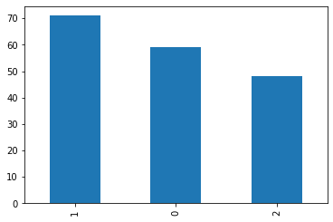

```python
print(df.shape)
df['target'].value_counts().plot(kind='bar')
```

It's the time for us to use our classifier, in a near-naïve way. We only use cross validation to train the model well. We can either try to determine the best hyperparameters.

```python
from sklearn.neighbors import KNeighborsClassifier
from sklearn.model_selection import cross_val_score, cross_val_predict, LeaveOneOut

# first prepare our features and target
X = df.drop('target', axis='columns')
y = df['target']

# select our cross validation iterator
cvi = LeaveOneOut()

# model selection, determine the best k-neighbors value for the set
scores = []
ks = [x for x in range(0,30) if(x%2!=0)]
for k in ks:
    # create classifier
    knn = KNeighborsClassifier(n_neighbors=k)
    # cross validation with 5 folds
    a = cross_val_score(knn, X, y, cv=cvi)
    scores.append(a)
```

Plotting the results to see for which K, KNN works the best.

```
0.6629213483146067 : 0.7696629213483146
```

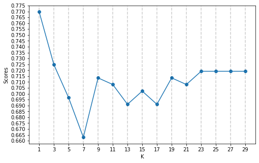

```python
fig, ax = plt.subplots(figsize=(8,5))

ax.set_xlabel('K')
ax.set_ylabel('Scores')

ax.set_xticks(ks)
ax.set_yticks(np.arange(0, 1,0.005))

# compute the avg accuracy score of each cross validation step
smean = [sum(scores[i])/X.shape[0] for i in range(len(scores))]
ax.plot(ks, smean, marker='o')

print("{} : {}".format(np.min(smean), np.max(smean)))

for i in ks:
    ax.axvline(i, alpha=0.2, linestyle='dashed', color='black')
```

The result of the previous plot shows that k-nn works well on those sets with a given k=1. Accuracy results are still low : it can be the fingerprint of a well-known problem called the curse of dimensionnality which says KNN performs better with a lower number of features than a large number of features. We need to lower the dimensions.

```python
print(X.shape)
```

```
(178, 13)
```

Before doing any kind of feature selection, we need to oper normalization on datas since they are disparate for the moment. Leaving datas in this state will seriously impact the relationships between variables.

```python
from sklearn.preprocessing import MinMaxScaler

mmscaler = MinMaxScaler()
X = pd.DataFrame(mmscaler.fit_transform(X), columns=X.columns, index=X.index)

X
```

|  | alcohol | malic_acid | ash | alcalinity_of_ash | magnesium | total_phenols | flavanoids | nonflavanoid_phenols | proanthocyanins | color_intensity | hue | od280/od315_of_diluted_wines | proline |
| --- | --- | --- | --- | --- | --- | --- | --- | --- | --- | --- | --- | --- | --- |
| 0 | 0.842105 | 0.191700 | 0.572193 | 0.257732 | 0.619565 | 0.627586 | 0.573840 | 0.283019 | 0.593060 | 0.372014 | 0.455285 | 0.970696 | 0.561341 |
| 1 | 0.571053 | 0.205534 | 0.417112 | 0.030928 | 0.326087 | 0.575862 | 0.510549 | 0.245283 | 0.274448 | 0.264505 | 0.463415 | 0.780220 | 0.550642 |
| 2 | 0.560526 | 0.320158 | 0.700535 | 0.412371 | 0.336957 | 0.627586 | 0.611814 | 0.320755 | 0.757098 | 0.375427 | 0.447154 | 0.695971 | 0.646933 |
| 3 | 0.878947 | 0.239130 | 0.609626 | 0.319588 | 0.467391 | 0.989655 | 0.664557 | 0.207547 | 0.558360 | 0.556314 | 0.308943 | 0.798535 | 0.857347 |
| 4 | 0.581579 | 0.365613 | 0.807487 | 0.536082 | 0.521739 | 0.627586 | 0.495781 | 0.490566 | 0.444795 | 0.259386 | 0.455285 | 0.608059 | 0.325963 |
| ... | ... | ... | ... | ... | ... | ... | ... | ... | ... | ... | ... | ... | ... |
| 173 | 0.705263 | 0.970356 | 0.582888 | 0.510309 | 0.271739 | 0.241379 | 0.056962 | 0.735849 | 0.205047 | 0.547782 | 0.130081 | 0.172161 | 0.329529 |
| 174 | 0.623684 | 0.626482 | 0.598930 | 0.639175 | 0.347826 | 0.282759 | 0.086498 | 0.566038 | 0.315457 | 0.513652 | 0.178862 | 0.106227 | 0.336662 |
| 175 | 0.589474 | 0.699605 | 0.481283 | 0.484536 | 0.543478 | 0.210345 | 0.073840 | 0.566038 | 0.296530 | 0.761092 | 0.089431 | 0.106227 | 0.397290 |
| 176 | 0.563158 | 0.365613 | 0.540107 | 0.484536 | 0.543478 | 0.231034 | 0.071730 | 0.754717 | 0.331230 | 0.684300 | 0.097561 | 0.128205 | 0.400856 |
| 177 | 0.815789 | 0.664032 | 0.737968 | 0.716495 | 0.282609 | 0.368966 | 0.088608 | 0.811321 | 0.296530 | 0.675768 | 0.105691 | 0.120879 | 0.201141 |

178 rows × 13 columns

Let's now redo the previous steps with a drastic feature selection. The choice of features is done by evaluating the features' capability of being a good class fingerprint/mark, i.e. when the datas are characteristics of a class. We can try to redure our 13 dimensions matrix into a 4 dimensions one in regards to the curse of dimensionality (low number of samples implies low number of features).

To achieve this, we can compare the variance of each feature, since a high variance implies that the data points are spread out, reducing the chances that the datas are overlapping. We will pick the first three.

The last feature I have chosen is the color_intensity. I discovered its impact on the datas while attempting to write the first version of this notebook. I'll explain why it is good for us later on.

```python
print(X.var().sort_values(ascending=[False]).head(3))
```

```
od280/od315_of_diluted_wines    0.067636
nonflavanoid_phenols            0.055139
proline                         0.050451
dtype: float64
```

Hence, our X and y are...

```python
X2 = X[['od280/od315_of_diluted_wines', 'nonflavanoid_phenols', 'proline', 'color_intensity']]
y2 = y
```

We can use a scatterplot matrix to confirm or not our hypothesis.

```
array([[<matplotlib.axes._subplots.AxesSubplot object at 0x7f703eac3f10>,
      dtype=object)
```

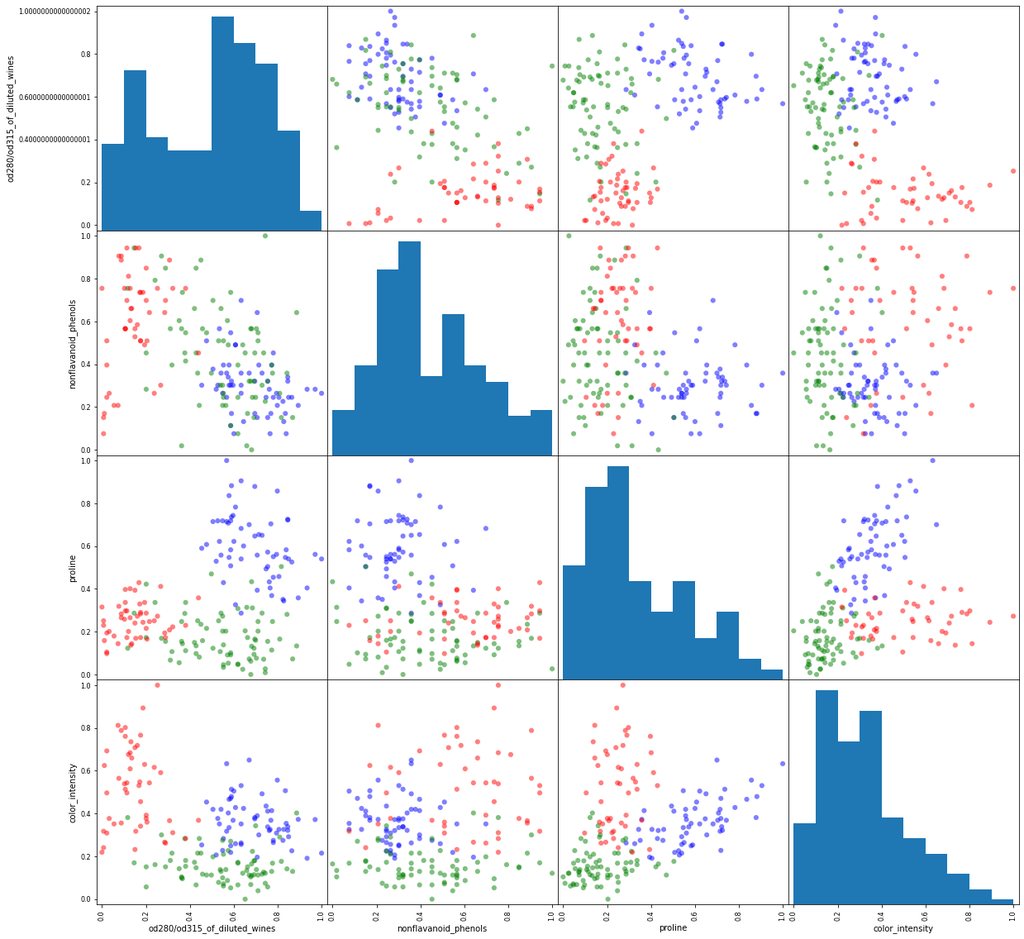

```python
from pandas.plotting import scatter_matrix

colormap=[]
for i in y2:
    if(i == 0):
        colormap.append('b')
    elif(i == 1):
        colormap.append('g')
    else:
        colormap.append('r')

scatter_matrix(X2, figsize=(20,20), c=colormap, s=150)
```

As we can see, all the classes aren't very well clustered in every pairs of variance-sensitive features. We can reduce our X to a single pair of features which seems to match our requirements. Here, it is (proline, od280/od315_of_diluted_wines). We can now replot it.

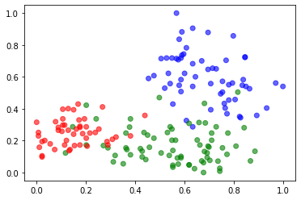

```python
fig2 = plt.figure()
ax2 = plt.axes()

ax2.scatter(X2[['od280/od315_of_diluted_wines']].values, X2[['proline']].values, alpha=0.6, c=colormap)
```

We can note that color_intensity corresponds to a bimodal distribution, i.e. there are two "bumps" on the histogram, saying the distribution encounters 2 values often. The clusters made versus proline and versus od280/od315_of_diluted_wines are quite interesting as well.

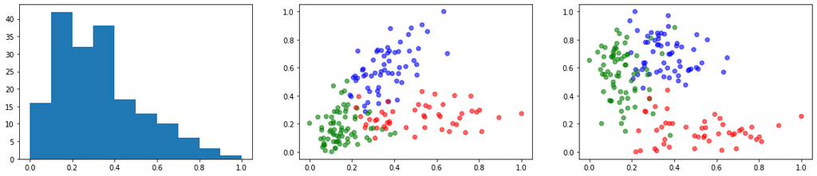

```python
fig, axs2 = plt.subplots(1, 3, figsize=(20,4))
axs2[0].hist(X2[['color_intensity']].values)
axs2[1].scatter(X2[['color_intensity']].values, X2[['proline']], alpha=0.6, c=colormap)
axs2[2].scatter(X2[['color_intensity']].values, X2[['od280/od315_of_diluted_wines']], alpha=0.6, c=colormap)
```

Plotting now each selected feature against each other, the clustered result seems to be good enough to expect good predicted results, except where the datas are overlapping.

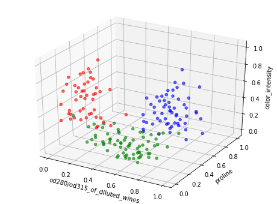

```python
fig2 = plt.figure(figsize=(8,6))
ax2 = plt.axes(projection='3d')
ax2.scatter(X2[['od280/od315_of_diluted_wines']].values, X2[['proline']].values, X2[['color_intensity']].values, alpha=0.6, c=colormap)
ax2.set_xlabel('od280/od315_of_diluted_wines')
ax2.set_ylabel('proline')
ax2.set_zlabel('color_intensity');
```

```python
X3 = X2[['od280/od315_of_diluted_wines', 'proline', 'color_intensity']]
y3 = y2

X3.head(2)
```

|  | od280/od315_of_diluted_wines | proline | color_intensity |
| --- | --- | --- | --- |
| 0 | 0.970696 | 0.561341 | 0.372014 |
| 1 | 0.780220 | 0.550642 | 0.264505 |

Time for predictions !

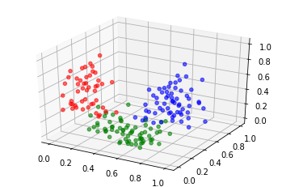

```python
knn3 = KNeighborsClassifier(n_neighbors=1)
results = cross_val_predict(knn3, X3, y3, cv=cvi) #cvi KFold()

colormap2=[]
for i in results:
    if(i == 0):
        colormap2.append('b')
    elif(i == 1):
        colormap2.append('g')
    else:
        colormap2.append('r')

fig3 = plt.figure()
ax3 = plt.axes(projection='3d')

ax3.scatter(X3[['od280/od315_of_diluted_wines']].values, X3[['proline']].values, X3[['color_intensity']].values, alpha=0.6, c=colormap2)
```

```python
from sklearn.metrics import accuracy_score

a=0
for i in range(len(y3)):
    if(y3[i] != results[i]):
        a = a+1

acc = accuracy_score(y3, results)
print('miss:{}/{} - acc:{}% - mse:{}'.format(a,len(y3), round(acc*100), 1-acc))
```

```
miss:12/178 - acc:93.0% - mse:0.0674157303370787
```

### Conclusions

Results are close to the results [those thesis writers](https://github.com/atomicwelding/papers/blob/master/data_science_ml_dl/pattern_recognition_methods_in_high_dimensional_settings_aeberhard_coomans_de_vel.pdf) obtained. We denote a difference of 3.1%